# Question

En el diagrama se muestran los datos estadísticos de participantes en un programa formativo, dependiendo del género y la edad.

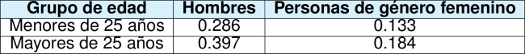

Por ejemplo, el 39.7% de los participantes son hombres mayores de 25 años. Según el diagrama, ¿cuál es la probabilidad de que al escoger una persona al azar pertenezca al grupo de los menores de 25 años, si ya se sabe que hace parte del grupo de hombres?

## Answerlist

- 0.133/0.683
- 0.286/0.581
- 0.683/0.286
- 0.286/0.683

# Solution

Para resolver este problema de **probabilidad condicional**, necesitamos aplicar correctamente la fórmula de probabilidad condicional y trabajar con la información de la tabla de contingencia.

### Paso 1: Identificar el tipo de problema y la fórmula

Este es un problema de **probabilidad condicional**, donde buscamos:

$$P(\text{menores de 25 años} |
\text{hombres})$$

La fórmula de probabilidad condicional es:
$$P(A|B) = \frac{P(A \cap B)}{P(B)}$$

Donde:

- $A$ = evento de interés: menores de 25 años
- $B$ = condición dada: hombres
- $P(A \cap B)$ = probabilidad de que ocurran ambos eventos simultáneamente
- $P(B)$ = probabilidad marginal de la condición

### Paso 2: Extraer información de la tabla de contingencia

De la tabla podemos obtener las siguientes **probabilidades conjuntas**:

- P(menores de 25 años $\cap$ hombres) = 0.286
- P(menores de 25 años $\cap$ personas de género femenino) = 0.133
- P(mayores de 25 años $\cap$ hombres) = 0.397
- P(mayores de 25 años $\cap$ personas de género femenino) = 0.184

### Paso 3: Calcular probabilidades marginales

Las **probabilidades marginales** se obtienen sumando las probabilidades conjuntas:

**Por género:**

- P(hombres) = 0.286 + 0.397 = 0.683
- P(personas de género femenino) = 0.133 + 0.184 = 0.317

**Por edad:**

- P(menores de 25 años) = 0.286 + 0.133 = 0.419
- P(mayores de 25 años) = 0.397 + 0.184 = 0.581

### Paso 4: Aplicar la fórmula para nuestro problema específico

Para nuestro problema:

$$P(\text{menores de 25 años} |
\text{hombres}) = \frac{P(\text{menores de 25 años} \cap
\text{hombres})}{P(\text{hombres})}$$

Sustituyendo los valores de la tabla:
$$P(\text{menores de 25 años} | \text{hombres}) =
\frac{0.286}{0.683}$$

### Paso 5: Verificación y análisis de distractores

**Respuesta correcta:** 0.286/0.683 = 0.419

**Análisis de errores conceptuales comunes (distractores):**

1. **0.286/0.581**: Error de **condición incorrecta** - usar el numerador correcto pero con una probabilidad marginal diferente como denominador
2. **0.133/0.683**: Error de **evento incorrecto** - usar el denominador correcto pero con una probabilidad conjunta diferente como numerador
3. **0.683/0.286**: Error de **intercambio P(A|B) con P(B|A)** - confundir la dirección de la probabilidad condicional invirtiendo numerador y denominador

### Conclusión

Por lo tanto, la probabilidad de que una persona pertenezca al grupo de menores de 25 años, dado que es hombres, es **0.286/0.683**.

Esta respuesta tiene sentido porque:

- El resultado está entre 0 y 1 (como toda probabilidad)
- El numerador representa la intersección de los dos eventos
- El denominador representa la probabilidad de la condición dada
- La interpretación es coherente con el contexto del problema

## Answerlist

- Falso
- Falso
- Falso
- Verdadero

# Meta-information

exname: probabilidad_condicional_tabla_contingencia_corregido extype: schoice exsolution: 0001 exshuffle: TRUE exsection: Probabilidad|Probabilidad condicional|Tablas de contingencia|Razonamiento matemático exextra[Type]: Cálculo exextra[Program]: R exextra[Language]: es exextra[Level]: 3